# Guided Project Business in SQL

Chenyu Wang

6/6/2020

This project will cooperate SQL in R to analyze chinook database, in the database, there are 11 tables in total describing a store purchase information.

First of all, I would like to import the package that can connect to SQLite library

```r
library(RSQLite)
library(DBI)
```

Create a run_query() helper function that takes in a SQL query as an argument and returns the result in a dataframe.

```r
# we will be using chinook.db
db <- 'chinook.db'

run_query <- function(q) {
  conn = dbConnect(SQLite(), db)
  result <- dbGetQuery(conn, q)
  dbDisconnect(conn)
  return(result)
}
```

Create a show_tables() function that calls the run_query() function to return a list of all tables and views in the datase.

```r
show_tables <- function() {
  q <- "SELECT name, type FROM sqlite_master WHERE type IN ('table', 'view')"
  return(run_query(q))
}

# run the show_tables function
show_tables()
```

```
##              name  type
## 1           album table
## 2          artist table
## 3        customer table
## 4        employee table
## 5           genre table
## 6         invoice table
## 7    invoice_line table
## 8      media_type table
## 9        playlist table
## 10 playlist_track table
## 11          track table
```

Now, I’m interested in learning which of the four genras are most popular in the US (Hip-Hop, Punk, Pop, and Blues) To do so, I will write a query that returns each genre, with the number of tracks sold in the USA in both absolute numbers and in percentages.

```r
albums_to_purchase = '
WITH usa_tracks_sold AS
   (
    SELECT il.* FROM invoice_line il
    INNER JOIN invoice i on il.invoice_id = i.invoice_id
    INNER JOIN customer c on i.customer_id = c.customer_id
    WHERE c.country = "USA"
   )
SELECT
    g.name genre,
    count(uts.invoice_line_id) tracks_sold,
    cast(count(uts.invoice_line_id) AS FLOAT) / (
        SELECT COUNT(*) from usa_tracks_sold
    ) percentage_sold
FROM usa_tracks_sold uts
INNER JOIN track t on t.track_id = uts.track_id
INNER JOIN genre g on g.genre_id = t.genre_id
GROUP BY 1
ORDER BY 2 DESC
LIMIT 10;
'

run_query(albums_to_purchase)
```

```
##                 genre tracks_sold percentage_sold
## 1                Rock         561      0.53377735
## 2  Alternative & Punk         130      0.12369172
## 3               Metal         124      0.11798287
## 4            R&B/Soul          53      0.05042816
## 5               Blues          36      0.03425309
## 6         Alternative          35      0.03330162
## 7                 Pop          22      0.02093245
## 8               Latin          22      0.02093245
## 9         Hip Hop/Rap          20      0.01902950
## 10               Jazz          14      0.01332065
```

With the table above, we then create a plot to show this finding.

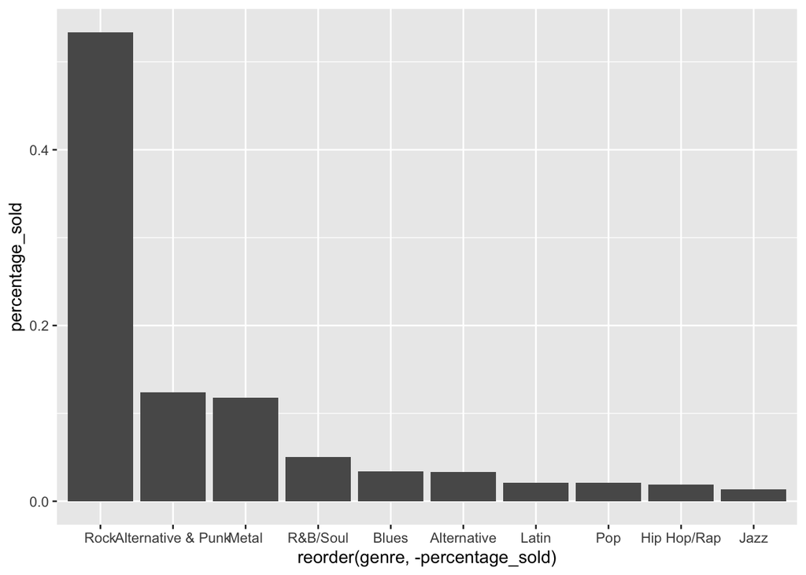

```r
library(ggplot2)
genre_sales = run_query(albums_to_purchase)
ggplot(data = genre_sales, aes(x = reorder(genre, -percentage_sold), y = percentage_sold)) +
  geom_bar(stat = "identity")
```

```r
  # labs(title = "something", x = "x", y = "y") +
  # theme(axis.title.x = element_text(angle = 45, hjust = 1))
```

Among the top 10 genres in the above graph, we find that for our 4 choices, punk, blues and pop are the highest sold. Therefore, we should recommen:

- Red Tone (Punk)
- Slim Jim Bites (Blues)
- Meteor and the Girls (Pop)

As we can clearly see in the graph, Rock makes up the majority of the sales. to better capture sales in the USA, we might want to ask the recod label if they have any up-and-coming rock bands.

Since each customer gets assigned to a sales support agent, I would like to see if any agent is performing either better or worse than the others.

```r
employee_sales_performance = '
WITH customer_support_rep_sales AS
    (
     SELECT
         i.customer_id,
         c.support_rep_id,
         SUM(i.total) total
     FROM invoice i
     INNER JOIN customer c ON i.customer_id = c.customer_id
     GROUP BY 1,2
    )
SELECT
    e.first_name || " " || e.last_name employee,
    e.hire_date,
    SUM(csrs.total) total_sales
FROM customer_support_rep_sales csrs
INNER JOIN employee e ON e.employee_id = csrs.support_rep_id
GROUP BY 1;
'

run_query(employee_sales_performance)
```

```
##        employee           hire_date total_sales
## 1  Jane Peacock 2017-04-01 00:00:00     1731.51
## 2 Margaret Park 2017-05-03 00:00:00     1584.00
## 3 Steve Johnson 2017-10-17 00:00:00     1393.92
```

With the table above, we create a graph to better visualize it

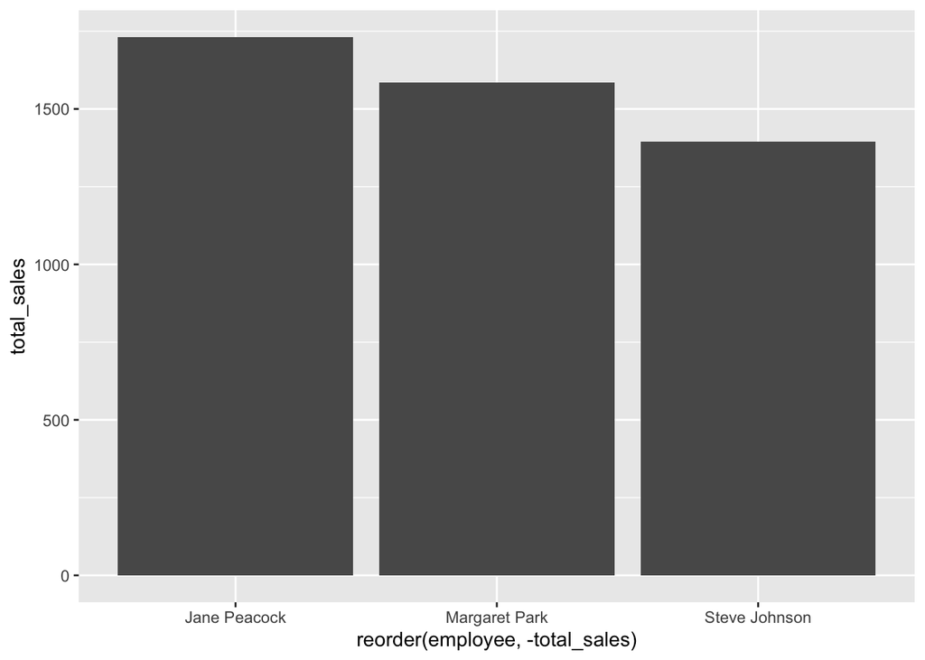

```r
employee_sales = run_query(employee_sales_performance)
ggplot(data = employee_sales, aes(x = reorder(employee, -total_sales), y = total_sales)) +
  geom_bar(stat = "identity")
```

According to the graph, we see that Jane Peacock has the highest amount of sales, but she also has been at the company the longest. If we want to see the true employee efficiency, we need to standardize sales by the number of days or hours worked.

Now we want to analyze the sales data for customers from each different country. I will use the country value from the customers table.

```r
sales_by_country = '
WITH country_or_other AS
  (
  SELECT
    CASE
      WHEN (
          SELECT COUNT(*)
          FROM customer
          WHERE country = c.country
      ) = 1 THEN "Other"
      ELSE c.country
    END AS country,
    c.customer_id,
    il.*
  FROM invoice_line il
  INNER JOIN invoice i ON i.invoice_id = il.invoice_id
  INNER JOIN customer c ON c.customer_id = i.customer_id
  )

SELECT
  country,
  customers,
  total_sales,
  average_order,
  customer_lifetime_value
FROM
  (
  SELECT
    country,
    count(distinct customer_id) customers,
    SUM(unit_price) total_sales,
    SUM(unit_price) / count(distinct customer_id) customer_lifetime_value,
    SUM(unit_price) / count(distinct invoice_id) average_order,
    CASE
      WHEN country = "Other" THEN 1
      ELSE 0
    END AS sort
  FROM country_or_other
  GROUP BY country
  ORDER BY sort ASC, total_sales DESC
  );
'

run_query(sales_by_country)
```

```
##           country customers total_sales average_order customer_lifetime_value
## 1             USA        13     1040.49      7.942672                80.03769
## 2          Canada         8      535.59      7.047237                66.94875
## 3          Brazil         5      427.68      7.011148                85.53600
## 4          France         5      389.07      7.781400                77.81400
## 5         Germany         4      334.62      8.161463                83.65500
## 6  Czech Republic         2      273.24      9.108000               136.62000
## 7  United Kingdom         3      245.52      8.768571                81.84000
## 8        Portugal         2      185.13      6.383793                92.56500
## 9           India         2      183.15      8.721429                91.57500
## 10          Other        15     1094.94      7.448571                72.99600
```

With the information above, I will create a graph demonstrating visually.

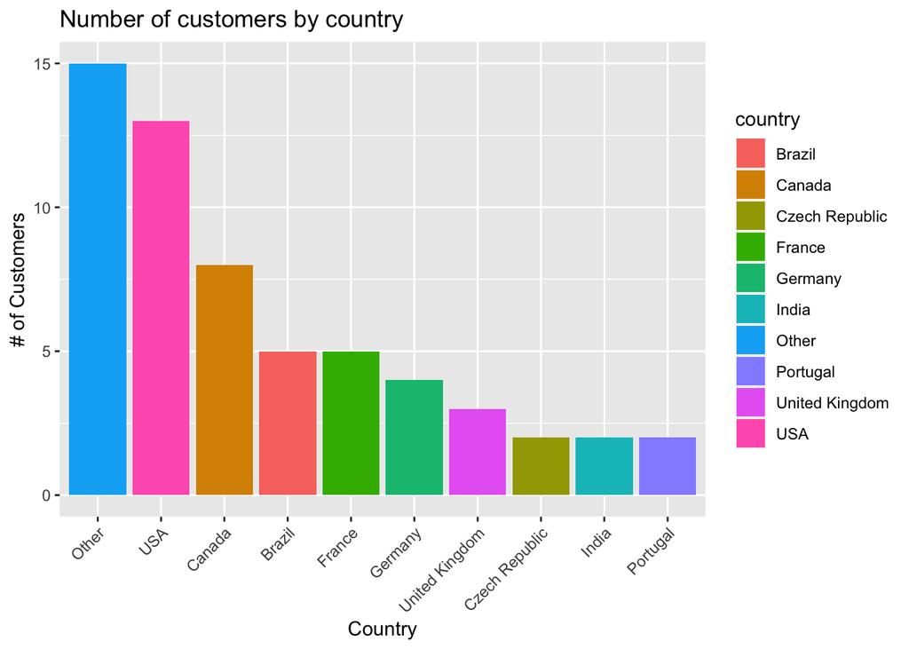

```r
country_info = run_query(sales_by_country)

# number of customers by country
ggplot(data = country_info, aes(x = reorder(country, -customers), y = customers, fill = country)) +
  geom_bar(stat = "identity") +
  labs(
    title = "Number of customers by country",
    x = "Country",
    y = "# of Customers"
  ) +
  theme(axis.text.x = element_text(angle = 45, hjust = 1))
```

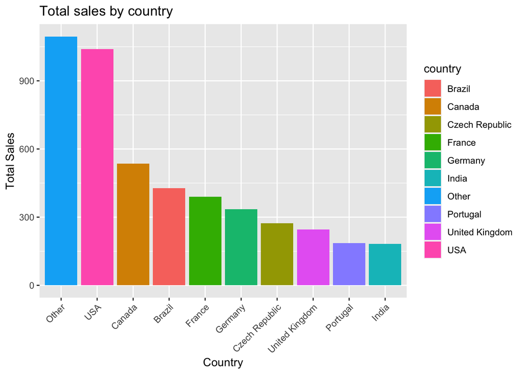

```r
# total sales by country
ggplot(data = country_info, aes(x = reorder(country, -total_sales), y = total_sales, fill = country)) +
  geom_bar(stat = "identity") +
  labs(
    title = "Total sales by country",
    x = "Country",
    y = "Total Sales"
  ) +
  theme(axis.text.x = element_text(angle = 45, hjust = 1))
```

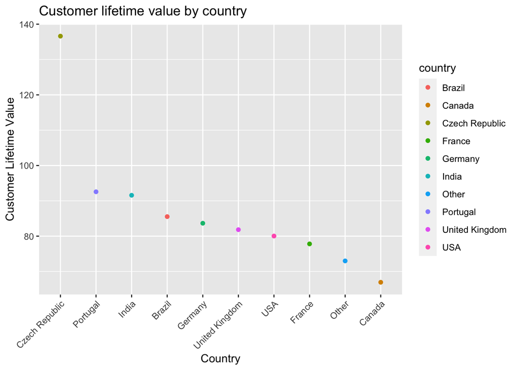

```r
# Customer lifetime value by country
ggplot(data = country_info, aes(x = reorder(country, -customer_lifetime_value), y = customer_lifetime_value, color = country)) +
  geom_point(stat = "identity") +
  labs(
    title = "Customer lifetime value by country",
    x = "Country",
    y = "Customer Lifetime Value"
  ) + theme(axis.text.x = element_text(angle = 45, hjust = 1))
```

In order to maximize revenue, the store is thinking about not purchasing all the individual tracks from an album, the goal for this part is to figure out the percentage of purchases are individual tracks versus whole albums.

```r
albums_vs_tracks = '
WITH invoice_first_track AS
    (
     SELECT
         il.invoice_id invoice_id,
         MIN(il.track_id) first_track_id
     FROM invoice_line il
     GROUP BY 1
    )

SELECT
  album_purchase,
  COUNT(invoice_id) number_of_invoices,
  CAST(COUNT(invoice_id) AS FLOAT) / (SELECT COUNT(*) FROM invoice) percent

FROM
  (
  SELECT
    ifs.*,
    CASE
      WHEN
        (
        SELECT t.track_id FROM track t
        WHERE t.album_id = (SELECT t2.album_id FROM track t2
                            WHERE t2.track_id = ifs.first_track_id
                            )
        EXCEPT
        SELECT il2.track_id FROM invoice_line il2
        WHERE il2.invoice_id = ifs.invoice_id
        ) IS NULL
      AND
        (
        SELECT il2.track_id FROM invoice_line il2
        WHERE il2.invoice_id = ifs.invoice_id
        EXCEPT
        SELECT t.track_id FROM track t
        WHERE t.album_id = (SELECT t2.album_id FROM track t2
                            WHERE t2.track_id = ifs.first_track_id
                            )
        ) IS NULL
      THEN "yes"
      ELSE "no"
    END AS "album_purchase"
  FROM invoice_first_track ifs
  )

GROUP BY album_purchase;
'
run_query(albums_vs_tracks)
```

```
##   album_purchase number_of_invoices   percent
## 1             no                500 0.8143322
## 2            yes                114 0.1856678
```